# 📊 BÁO CÁO PHÂN TÍCH DỮ LIỆU - HOUSE PRICES PREDICTION

**Tác giả:** Team SGU 25 ML Fundamental  
**Ngày:** 2025  
**Dataset:** House Prices - Advanced Regression Techniques (Kaggle)  
**Mục tiêu:** Dự đoán giá nhà dựa trên các đặc điểm bất động sản

## 📋 Mục lục

1. Giới thiệu
2. Mô tả dữ liệu
3. Phân tích khám phá dữ liệu (EDA)
4. Xử lý dữ liệu
5. Xây dựng mô hình
6. Kết quả và thảo luận
7. Kết luận và kiến nghị
8. Tài liệu tham khảo

# 1. GIỚI THIỆU (Introduction)

## 1.1. Bối cảnh và mục tiêu nghiên cứu

Dự đoán giá nhà là một trong những bài toán quan trọng trong lĩnh vực bất động sản và machine learning. Việc dự đoán chính xác giá nhà giúp:

- **Người mua nhà**: Đưa ra quyết định đầu tư hợp lý
- **Người bán nhà**: Định giá bán phù hợp với thị trường
- **Công ty bất động sản**: Tư vấn khách hàng và quản lý danh mục
- **Ngân hàng**: Đánh giá giá trị tài sản thế chấp

**Mục tiêu nghiên cứu:**

- Phân tích các yếu tố ảnh hưởng đến giá nhà
- Xây dựng mô hình dự đoán giá nhà chính xác
- So sánh hiệu quả của các thuật toán machine learning khác nhau

## 1.2. Mô tả tổng quan về bộ dữ liệu

Dataset **House Prices - Advanced Regression Techniques** từ Kaggle chứa thông tin về 1460 ngôi nhà tại Ames, Iowa, Hoa Kỳ, với 80 đặc trưng mô tả các khía cạnh khác nhau của từng ngôi nhà như:

- Đặc điểm địa lý (khu vực, vị trí)
- Đặc điểm kiến trúc (kiểu nhà, diện tích, số phòng)
- Chất lượng và điều kiện (đánh giá tổng thể, năm xây dựng)
- Tiện ích (garage, basement, hồ bơi, v.v.)

## 1.3. Các câu hỏi nghiên cứu

1. **Yếu tố nào ảnh hưởng mạnh nhất đến giá nhà?**
2. **Mối quan hệ giữa diện tích và giá nhà như thế nào?**
3. **Khu vực (Neighborhood) có ảnh hưởng đáng kể đến giá nhà không?**
4. **Mô hình nào cho kết quả dự đoán tốt nhất?**

## 1.4. Ý nghĩa thực tiễn

Bài toán này có ứng dụng thực tế cao trong:

- **Định giá bất động sản tự động**: Hỗ trợ định giá nhanh chóng và chính xác
- **Phân tích thị trường**: Hiểu rõ các yếu tố ảnh hưởng đến giá nhà
- **Đầu tư thông minh**: Giúp nhà đầu tư đưa ra quyết định dựa trên dữ liệu

```python
# Import các thư viện cần thiết
import pandas as pd
import numpy as np
import matplotlib.pyplot as plt
import seaborn as sns
import warnings
import sys
import os
from pathlib import Path

# Thêm thư mục gốc của dự án vào sys.path (thư mục chứa src)
# Notebook này nằm trong reports/, nên cần đi lên 1 cấp để đến thư mục gốc
current_dir = os.getcwd()

# Nếu đang ở thư mục reports, đi lên 1 cấp
if current_dir.endswith('reports') or current_dir.endswith('reports\\') or current_dir.endswith('reports/'):
    project_root = os.path.abspath(os.path.join(current_dir, '..'))
else:
    # Nếu đang ở thư mục gốc, sử dụng thư mục hiện tại
    project_root = current_dir

# Đảm bảo thư mục src tồn tại
if not os.path.exists(os.path.join(project_root, 'src')):
    # Thử tìm thư mục src từ các vị trí khác
    possible_paths = [
        os.path.abspath('..'),  # Thư mục cha
        os.path.abspath('../..'),  # Thư mục ông
        os.path.join(os.path.dirname(os.path.abspath('.')), '..'),  # Thư mục cha của thư mục hiện tại
    ]
    for path in possible_paths:
        if os.path.exists(os.path.join(path, 'src')):
            project_root = os.path.abspath(path)
            break

if project_root not in sys.path:
    sys.path.insert(0, project_root)

print(f"📁 Project root: {project_root}")
print(f"📁 Checking for src: {os.path.exists(os.path.join(project_root, 'src'))}")

# Cấu hình hiển thị
warnings.filterwarnings('ignore')
pd.set_option('display.max_columns', None)
pd.set_option('display.max_rows', 100)
sns.set_style("whitegrid")
plt.rcParams['figure.figsize'] = (12, 6)
plt.rcParams['font.size'] = 10

# Import các module từ dự án
try:
    from src.eda.eda import EDA
    from src.preprocess.clean.clean import DataCleaner, Clean
    from src.preprocess.preprocess.preprocess import Preprocess
    from src.preprocess.feature.feature import Feature
    from src.model.LightGBM import ModelLightGBM
    from src.model.Lasso import ModelLasso
    from src.evaluation.evaluation import Evaluation
    print("✅ Đã import tất cả thư viện thành công!")
except ImportError as e:
    print(f"⚠️ Lỗi import: {e}")
    print(f"📁 Current working directory: {os.getcwd()}")
    print(f"📁 Project root: {project_root}")
    print(f"📁 Checking src exists: {os.path.exists(os.path.join(project_root, 'src'))}")
    print(f"📁 sys.path đầu tiên: {sys.path[0] if sys.path else 'None'}")
    raise
```

[output not shown]

```python
# Load dữ liệu
train_path = '../data/raw/train.csv'
test_path = '../data/raw/test.csv'

df_train = pd.read_csv(train_path)
df_test = pd.read_csv(test_path)

print(f"📊 Train dataset shape: {df_train.shape}")
print(f"📊 Test dataset shape: {df_test.shape}")
print(f"\n📋 Các cột trong train dataset:")
print(df_train.columns.tolist())
```

[output not shown]

# 2. MÔ TẢ DỮ LIỆU (Data Description)

## 2.1. Nguồn gốc dữ liệu

Dataset được lấy từ cuộc thi **House Prices - Advanced Regression Techniques** trên Kaggle:

- **Link**: https://www.kaggle.com/c/house-prices-advanced-regression-techniques
- **Nguồn**: Ames Housing dataset
- **Mô tả**: Thông tin về các ngôi nhà tại Ames, Iowa, Hoa Kỳ từ năm 2006 đến 2010

## 2.2. Số lượng quan sát và biến số

```python
# Thống kê tổng quan về dataset
print("="*70)
print("📊 TỔNG QUAN DATASET")
print("="*70)

info_summary = pd.DataFrame({
    'Thông tin': [
        'Số lượng quan sát (train)',
        'Số lượng quan sát (test)',
        'Tổng số biến (features)',
        'Biến số (Numerical)',
        'Biến phân loại (Categorical)',
        'Biến mục tiêu (Target)'
    ],
    'Giá trị': [
        df_train.shape[0],
        df_test.shape[0],
        df_train.shape[1] - 1,  # Trừ cột SalePrice
        len(df_train.select_dtypes(include=[np.number]).columns) - 1,  # Trừ SalePrice
        len(df_train.select_dtypes(exclude=[np.number]).columns),
        'SalePrice'
    ]
})

print(info_summary.to_string(index=False))

# Phân loại các biến
numerical_cols = df_train.select_dtypes(include=[np.number]).columns.tolist()
categorical_cols = df_train.select_dtypes(exclude=[np.number]).columns.tolist()

if 'SalePrice' in numerical_cols:
    numerical_cols.remove('SalePrice')
if 'Id' in numerical_cols:
    numerical_cols.remove('Id')

print(f"\n📊 Số biến số: {len(numerical_cols)}")
print(f"📊 Số biến phân loại: {len(categorical_cols)}")
```

```
======================================================================
📊 TỔNG QUAN DATASET
======================================================================
                   Thông tin   Giá trị
   Số lượng quan sát (train)      1460
    Số lượng quan sát (test)      1459
     Tổng số biến (features)        80
         Biến số (Numerical)        37
Biến phân loại (Categorical)        43
      Biến mục tiêu (Target) SalePrice

📊 Số biến số: 36
📊 Số biến phân loại: 43
```

## 2.3. Bảng mô tả chi tiết các biến

Dưới đây là mô tả một số biến quan trọng trong dataset:

### Biến số (Numerical Variables) quan trọng:

- **SalePrice**: Giá bán nhà (biến mục tiêu)
- **GrLivArea**: Diện tích sống trên mặt đất (square feet)
- **LotArea**: Diện tích lô đất (square feet)
- **OverallQual**: Đánh giá chất lượng tổng thể (1-10)
- **OverallCond**: Đánh giá điều kiện tổng thể (1-10)
- **YearBuilt**: Năm xây dựng
- **TotalBsmtSF**: Tổng diện tích tầng hầm (square feet)

### Biến phân loại (Categorical Variables) quan trọng:

- **Neighborhood**: Khu vực địa lý
- **HouseStyle**: Kiểu nhà
- **MSZoning**: Phân loại vùng
- **SaleCondition**: Điều kiện bán
- **Foundation**: Loại móng nhà

```python
# Hiển thị mô tả các biến quan trọng
important_vars = [
    'SalePrice', 'GrLivArea', 'LotArea', 'OverallQual', 'OverallCond',
    'YearBuilt', 'TotalBsmtSF', '1stFlrSF', '2ndFlrSF', 'GarageArea',
    'Neighborhood', 'HouseStyle', 'MSZoning', 'SaleCondition', 'Foundation'
]

available_vars = [var for var in important_vars if var in df_train.columns]

print("📋 MÔ TẢ CÁC BIẾN QUAN TRỌNG:")
print("="*70)

for var in available_vars[:10]:  # Hiển thị 10 biến đầu
    if var in df_train.columns:
        print(f"\n🔹 {var}:")
        print(f"   - Kiểu dữ liệu: {df_train[var].dtype}")
        print(f"   - Giá trị duy nhất: {df_train[var].nunique()}")
        if df_train[var].dtype in ['int64', 'float64']:
            print(f"   - Min: {df_train[var].min()}, Max: {df_train[var].max()}")
            print(f"   - Mean: {df_train[var].mean():.2f}, Median: {df_train[var].median():.2f}")
        else:
            print(f"   - Top 3 giá trị: {df_train[var].value_counts().head(3).to_dict()}")
```

```
📋 MÔ TẢ CÁC BIẾN QUAN TRỌNG:
======================================================================

🔹 SalePrice:
   - Kiểu dữ liệu: int64
   - Giá trị duy nhất: 663
   - Min: 34900, Max: 755000
   - Mean: 180921.20, Median: 163000.00

🔹 GrLivArea:
   - Kiểu dữ liệu: int64
   - Giá trị duy nhất: 861
   - Min: 334, Max: 5642
   - Mean: 1515.46, Median: 1464.00

🔹 LotArea:
   - Kiểu dữ liệu: int64
   - Giá trị duy nhất: 1073
   - Min: 1300, Max: 215245
   - Mean: 10516.83, Median: 9478.50

🔹 OverallQual:
   - Kiểu dữ liệu: int64
   - Giá trị duy nhất: 10
   - Min: 1, Max: 10
   - Mean: 6.10, Median: 6.00

🔹 OverallCond:
   - Kiểu dữ liệu: int64
   - Giá trị duy nhất: 9
   - Min: 1, Max: 9
   - Mean: 5.58, Median: 5.00

🔹 YearBuilt:
   - Kiểu dữ liệu: int64
   - Giá trị duy nhất: 112
   - Min: 1872, Max: 2010
   - Mean: 1971.27, Median: 1973.00

🔹 TotalBsmtSF:
   - Kiểu dữ liệu: int64
   - Giá trị duy nhất: 721
   - Min: 0, Max: 6110
   - Mean: 1057.43, Median: 991.50

🔹 1stFlrSF:
   - Kiểu dữ liệu: int64
   - Giá trị duy nhất: 753
   - Min: 334, Max: 4692
   - Mean: 1162.63, Median: 1087.00

🔹 2ndFlrSF:
   - Kiểu dữ liệu: int64
   - Giá trị duy nhất: 417
   - Min: 0, Max: 2065
   - Mean: 346.99, Median: 0.00

🔹 GarageArea:
   - Kiểu dữ liệu: int64
   - Giá trị duy nhất: 441
   - Min: 0, Max: 1418
   - Mean: 472.98, Median: 480.00
```

# 3. PHÂN TÍCH KHÁM PHÁ DỮ LIỆU (Exploratory Data Analysis - EDA)

## 3.1. Thống kê mô tả

### 3.1.1. Thống kê tóm tắt

```python
# Thống kê mô tả cho biến mục tiêu và các biến số quan trọng
print("="*70)
print("📊 THỐNG KÊ MÔ TẢ - BIẾN MỤC TIÊU (SalePrice)")
print("="*70)

target_stats = df_train['SalePrice'].describe()
print(target_stats)

# Tính thêm các thống kê khác
skewness = df_train['SalePrice'].skew()
kurtosis = df_train['SalePrice'].kurtosis()

print(f"\n📈 Độ lệch (Skewness): {skewness:.4f}")
print(f"📈 Độ nhọn (Kurtosis): {kurtosis:.4f}")

# Thống kê cho các biến số quan trọng
important_num_cols = ['GrLivArea', 'LotArea', 'OverallQual', 'OverallCond',
                      'YearBuilt', 'TotalBsmtSF', 'GarageArea']
available_num_cols = [col for col in important_num_cols if col in df_train.columns]

print("\n" + "="*70)
print("📊 THỐNG KÊ MÔ TẢ - CÁC BIẾN SỐ QUAN TRỌNG")
print("="*70)
print(df_train[available_num_cols].describe().T)
```

```
======================================================================
📊 THỐNG KÊ MÔ TẢ - BIẾN MỤC TIÊU (SalePrice)
======================================================================
count      1460.000000
mean     180921.195890
std       79442.502883
min       34900.000000
25%      129975.000000
50%      163000.000000
75%      214000.000000
max      755000.000000
Name: SalePrice, dtype: float64

📈 Độ lệch (Skewness): 1.8829
📈 Độ nhọn (Kurtosis): 6.5363

======================================================================
📊 THỐNG KÊ MÔ TẢ - CÁC BIẾN SỐ QUAN TRỌNG
======================================================================
              count          mean          std     min      25%     50%  \
GrLivArea    1460.0   1515.463699   525.480383   334.0  1129.50  1464.0
LotArea      1460.0  10516.828082  9981.264932  1300.0  7553.50  9478.5
OverallQual  1460.0      6.099315     1.382997     1.0     5.00     6.0
OverallCond  1460.0      5.575342     1.112799     1.0     5.00     5.0
YearBuilt    1460.0   1971.267808    30.202904  1872.0  1954.00  1973.0
TotalBsmtSF  1460.0   1057.429452   438.705324     0.0   795.75   991.5
GarageArea   1460.0    472.980137   213.804841     0.0   334.50   480.0

                  75%       max
GrLivArea     1776.75    5642.0
LotArea      11601.50  215245.0
OverallQual      7.00      10.0
OverallCond      6.00       9.0
YearBuilt     2000.00    2010.0
TotalBsmtSF   1298.25    6110.0
GarageArea     576.00    1418.0
```

### 3.1.2. Phân tích phân phối của các biến số

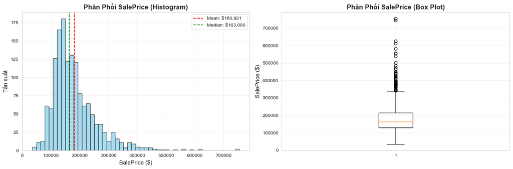

```
📊 Nhận xét về phân phối SalePrice:
   - Phân phối lệch phải (Right-skewed): Skewness = 1.8829
   - Có nhiều giá trị ngoại lai ở phía trên
   - Median < Mean: $163,000 < $180,921
```

```python
# Phân tích phân phối SalePrice
fig, axes = plt.subplots(1, 2, figsize=(15, 5))

# Histogram
axes[0].hist(df_train['SalePrice'], bins=50, color='skyblue', edgecolor='black', alpha=0.7)
axes[0].set_title('Phân Phối SalePrice (Histogram)', fontsize=14, fontweight='bold')
axes[0].set_xlabel('SalePrice ($)', fontsize=12)
axes[0].set_ylabel('Tần suất', fontsize=12)
axes[0].axvline(df_train['SalePrice'].mean(), color='red', linestyle='--',
                label=f'Mean: ${df_train["SalePrice"].mean():,.0f}')
axes[0].axvline(df_train['SalePrice'].median(), color='green', linestyle='--',
                label=f'Median: ${df_train["SalePrice"].median():,.0f}')
axes[0].legend()
axes[0].grid(True, alpha=0.3)

# Box plot
axes[1].boxplot(df_train['SalePrice'], vert=True)
axes[1].set_title('Phân Phối SalePrice (Box Plot)', fontsize=14, fontweight='bold')
axes[1].set_ylabel('SalePrice ($)', fontsize=12)
axes[1].grid(True, alpha=0.3)

plt.tight_layout()
plt.savefig('../reports/figures/saleprice_distribution.png', dpi=300, bbox_inches='tight')
plt.show()

print("📊 Nhận xét về phân phối SalePrice:")
print(f"   - Phân phối lệch phải (Right-skewed): Skewness = {skewness:.4f}")
print(f"   - Có nhiều giá trị ngoại lai ở phía trên")
print(f"   - Median < Mean: ${df_train['SalePrice'].median():,.0f} < ${df_train['SalePrice'].mean():,.0f}")
```

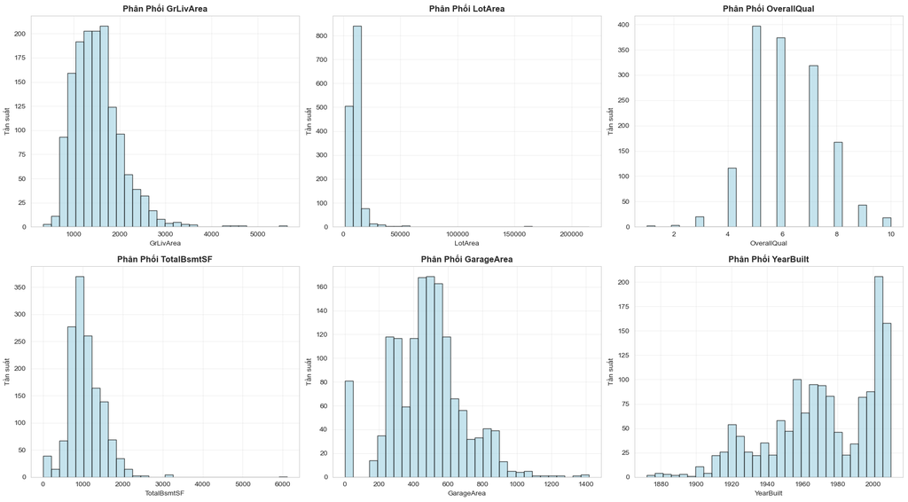

```python
# Phân tích phân phối các biến số quan trọng
fig, axes = plt.subplots(2, 3, figsize=(18, 10))
axes = axes.ravel()

important_vars_dist = ['GrLivArea', 'LotArea', 'OverallQual', 'TotalBsmtSF', 'GarageArea', 'YearBuilt']
available_vars_dist = [col for col in important_vars_dist if col in df_train.columns]

for idx, var in enumerate(available_vars_dist[:6]):
    axes[idx].hist(df_train[var], bins=30, color='lightblue', edgecolor='black', alpha=0.7)
    axes[idx].set_title(f'Phân Phối {var}', fontsize=12, fontweight='bold')
    axes[idx].set_xlabel(var, fontsize=10)
    axes[idx].set_ylabel('Tần suất', fontsize=10)
    axes[idx].grid(True, alpha=0.3)

plt.tight_layout()
plt.savefig('../reports/figures/numerical_distributions.png', dpi=300, bbox_inches='tight')
plt.show()
```

### 3.1.3. Phân tích tần suất của các biến phân loại

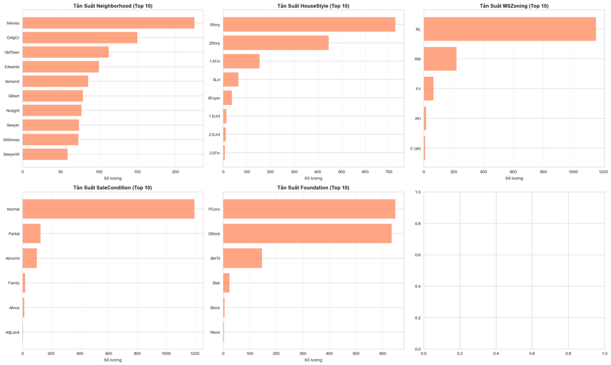

```python
# Phân tích tần suất các biến phân loại quan trọng
categorical_important = ['Neighborhood', 'HouseStyle', 'MSZoning', 'SaleCondition', 'Foundation']
available_cat = [col for col in categorical_important if col in df_train.columns]

fig, axes = plt.subplots(2, 3, figsize=(20, 12))
axes = axes.ravel()

for idx, var in enumerate(available_cat[:6]):
    value_counts = df_train[var].value_counts().head(10)
    axes[idx].barh(range(len(value_counts)), value_counts.values, color='coral', alpha=0.7)
    axes[idx].set_yticks(range(len(value_counts)))
    axes[idx].set_yticklabels(value_counts.index, fontsize=9)
    axes[idx].set_title(f'Tần Suất {var} (Top 10)', fontsize=12, fontweight='bold')
    axes[idx].set_xlabel('Số lượng', fontsize=10)
    axes[idx].grid(True, alpha=0.3, axis='x')
    # Đảo ngược thứ tự để hiển thị từ cao xuống thấp
    axes[idx].invert_yaxis()

plt.tight_layout()
plt.savefig('../reports/figures/categorical_frequencies.png', dpi=300, bbox_inches='tight')
plt.show()
```

## 3.2. Trực quan hóa dữ liệu

### 3.2.1. Biểu đồ phân phối (Histograms, Boxplots)

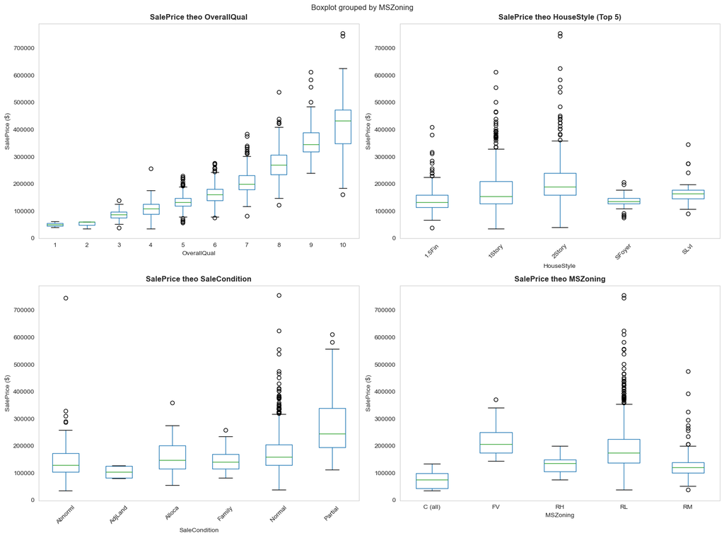

```python
# Box plots so sánh SalePrice theo các biến phân loại
fig, axes = plt.subplots(2, 2, figsize=(16, 12))

# SalePrice theo OverallQual
if 'OverallQual' in df_train.columns:
    df_train.boxplot(column='SalePrice', by='OverallQual', ax=axes[0,0], grid=False)
    axes[0,0].set_title('SalePrice theo OverallQual', fontsize=12, fontweight='bold')
    axes[0,0].set_xlabel('OverallQual', fontsize=10)
    axes[0,0].set_ylabel('SalePrice ($)', fontsize=10)

# SalePrice theo HouseStyle (top 5)
if 'HouseStyle' in df_train.columns:
    top_house_styles = df_train['HouseStyle'].value_counts().head(5).index
    df_filtered = df_train[df_train['HouseStyle'].isin(top_house_styles)]
    df_filtered.boxplot(column='SalePrice', by='HouseStyle', ax=axes[0,1], grid=False)
    axes[0,1].set_title('SalePrice theo HouseStyle (Top 5)', fontsize=12, fontweight='bold')
    axes[0,1].set_xlabel('HouseStyle', fontsize=10)
    axes[0,1].set_ylabel('SalePrice ($)', fontsize=10)
    plt.setp(axes[0,1].xaxis.get_majorticklabels(), rotation=45)

# SalePrice theo SaleCondition
if 'SaleCondition' in df_train.columns:
    df_train.boxplot(column='SalePrice', by='SaleCondition', ax=axes[1,0], grid=False)
    axes[1,0].set_title('SalePrice theo SaleCondition', fontsize=12, fontweight='bold')
    axes[1,0].set_xlabel('SaleCondition', fontsize=10)
    axes[1,0].set_ylabel('SalePrice ($)', fontsize=10)
    plt.setp(axes[1,0].xaxis.get_majorticklabels(), rotation=45)

# SalePrice theo MSZoning
if 'MSZoning' in df_train.columns:
    df_train.boxplot(column='SalePrice', by='MSZoning', ax=axes[1,1], grid=False)
    axes[1,1].set_title('SalePrice theo MSZoning', fontsize=12, fontweight='bold')
    axes[1,1].set_xlabel('MSZoning', fontsize=10)
    axes[1,1].set_ylabel('SalePrice ($)', fontsize=10)

plt.tight_layout()
plt.savefig('../reports/figures/saleprice_by_categorical.png', dpi=300, bbox_inches='tight')
plt.show()
```

### 3.2.2. Biểu đồ tương quan (Correlation Heatmap)

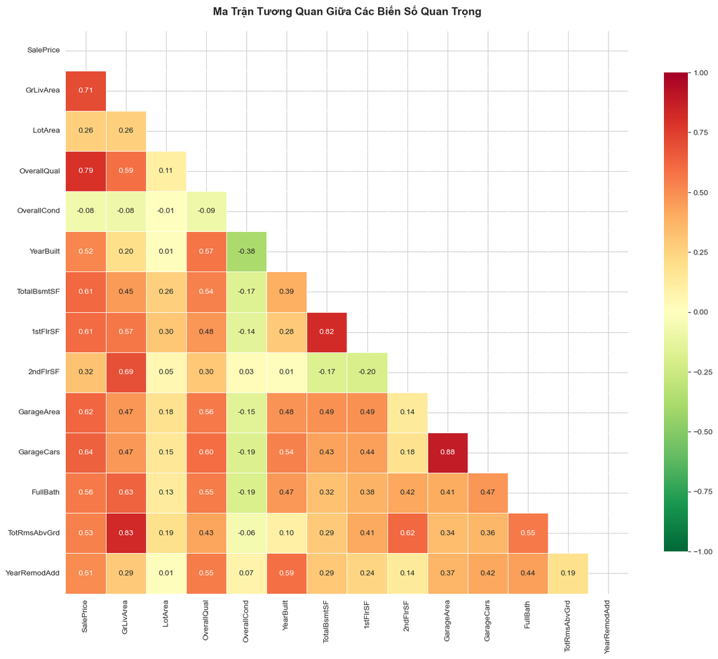

```
📊 TOP 10 BIẾN TƯƠNG QUAN MẠNH NHẤT VỚI SalePrice:
======================================================================
  OverallQual         : 0.7910
  GrLivArea           : 0.7086
  GarageCars          : 0.6404
  GarageArea          : 0.6234
  TotalBsmtSF         : 0.6136
  1stFlrSF            : 0.6059
  FullBath            : 0.5607
  TotRmsAbvGrd        : 0.5337
  YearBuilt           : 0.5229
  YearRemodAdd        : 0.5071
```

```python
# Tính ma trận tương quan cho các biến số
corr_cols = ['SalePrice', 'GrLivArea', 'LotArea', 'OverallQual', 'OverallCond',
             'YearBuilt', 'TotalBsmtSF', '1stFlrSF', '2ndFlrSF', 'GarageArea',
             'GarageCars', 'FullBath', 'TotRmsAbvGrd', 'YearRemodAdd']

available_corr_cols = [col for col in corr_cols if col in df_train.columns]
correlation_matrix = df_train[available_corr_cols].corr()

# Vẽ heatmap
plt.figure(figsize=(14, 12))
mask = np.triu(np.ones_like(correlation_matrix, dtype=bool))
sns.heatmap(correlation_matrix, mask=mask, annot=True, fmt='.2f', cmap='RdYlGn_r',
            center=0, square=True, linewidths=0.5, cbar_kws={"shrink": 0.8},
            vmin=-1, vmax=1)
plt.title('Ma Trận Tương Quan Giữa Các Biến Số Quan Trọng',
          fontsize=14, fontweight='bold', pad=20)
plt.tight_layout()
plt.savefig('../reports/figures/correlation_heatmap.png', dpi=300, bbox_inches='tight')
plt.show()

# Tìm các biến tương quan mạnh nhất với SalePrice
if 'SalePrice' in correlation_matrix.columns:
    sale_price_corr = correlation_matrix['SalePrice'].drop('SalePrice').sort_values(ascending=False)
    print("\n📊 TOP 10 BIẾN TƯƠNG QUAN MẠNH NHẤT VỚI SalePrice:")
    print("="*70)
    for var, corr in sale_price_corr.head(10).items():
        print(f"  {var:20s}: {corr:6.4f}")
```

### 3.2.3. Biểu đồ phân tích mối quan hệ giữa các biến

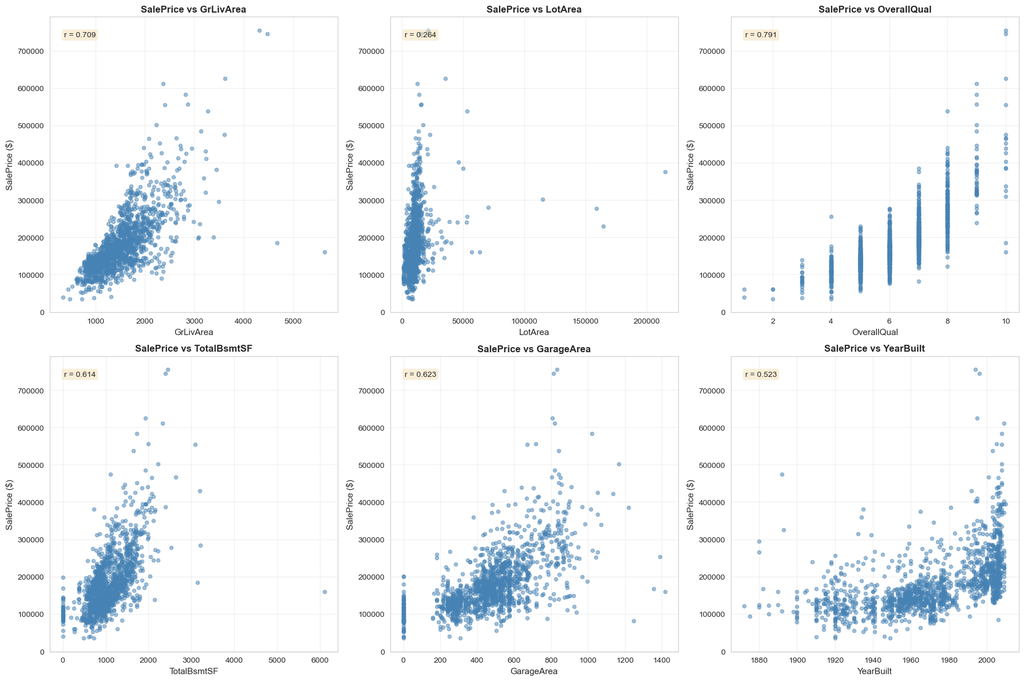

```python
# Scatter plots: Mối quan hệ giữa SalePrice và các biến số quan trọng
fig, axes = plt.subplots(2, 3, figsize=(18, 12))
axes = axes.ravel()

scatter_vars = ['GrLivArea', 'LotArea', 'OverallQual', 'TotalBsmtSF', 'GarageArea', 'YearBuilt']
available_scatter = [col for col in scatter_vars if col in df_train.columns]

for idx, var in enumerate(available_scatter[:6]):
    axes[idx].scatter(df_train[var], df_train['SalePrice'], alpha=0.5, s=20, color='steelblue')
    axes[idx].set_xlabel(var, fontsize=11)
    axes[idx].set_ylabel('SalePrice ($)', fontsize=11)
    axes[idx].set_title(f'SalePrice vs {var}', fontsize=12, fontweight='bold')
    axes[idx].grid(True, alpha=0.3)

    # Tính hệ số tương quan
    corr = df_train[var].corr(df_train['SalePrice'])
    axes[idx].text(0.05, 0.95, f'r = {corr:.3f}', transform=axes[idx].transAxes,
                   fontsize=10, verticalalignment='top',
                   bbox=dict(boxstyle='round', facecolor='wheat', alpha=0.5))

plt.tight_layout()
plt.savefig('../reports/figures/scatter_relationships.png', dpi=300, bbox_inches='tight')
plt.show()
```

## 3.3. Phát hiện insight

### 3.3.1. Các xu hướng và pattern quan trọng

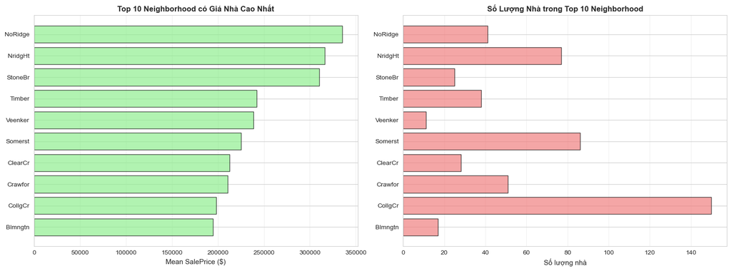

```
📊 TOP 10 NEIGHBORHOOD CÓ GIÁ NHÀ CAO NHẤT:
======================================================================
 1. NoRidge             : Mean=$335,295, Count=41.0
 2. NridgHt             : Mean=$316,271, Count=77.0
 3. StoneBr             : Mean=$310,499, Count=25.0
 4. Timber              : Mean=$242,247, Count=38.0
 5. Veenker             : Mean=$238,773, Count=11.0
 6. Somerst             : Mean=$225,380, Count=86.0
 7. ClearCr             : Mean=$212,565, Count=28.0
 8. Crawfor             : Mean=$210,625, Count=51.0
 9. CollgCr             : Mean=$197,966, Count=150.0
10. Blmngtn             : Mean=$194,871, Count=17.0
```

```python
# Phân tích SalePrice theo Neighborhood (top 10)
if 'Neighborhood' in df_train.columns:
    neighborhood_stats = df_train.groupby('Neighborhood')['SalePrice'].agg(['mean', 'median', 'count']).sort_values('mean', ascending=False).head(10)

    fig, axes = plt.subplots(1, 2, figsize=(16, 6))

    # Bar plot - Mean SalePrice
    axes[0].barh(range(len(neighborhood_stats)), neighborhood_stats['mean'].values,
                 color='lightgreen', alpha=0.7, edgecolor='black')
    axes[0].set_yticks(range(len(neighborhood_stats)))
    axes[0].set_yticklabels(neighborhood_stats.index, fontsize=10)
    axes[0].set_xlabel('Mean SalePrice ($)', fontsize=11)
    axes[0].set_title('Top 10 Neighborhood có Giá Nhà Cao Nhất', fontsize=12, fontweight='bold')
    axes[0].grid(True, alpha=0.3, axis='x')
    axes[0].invert_yaxis()

    # Bar plot - Count
    axes[1].barh(range(len(neighborhood_stats)), neighborhood_stats['count'].values,
                 color='lightcoral', alpha=0.7, edgecolor='black')
    axes[1].set_yticks(range(len(neighborhood_stats)))
    axes[1].set_yticklabels(neighborhood_stats.index, fontsize=10)
    axes[1].set_xlabel('Số lượng nhà', fontsize=11)
    axes[1].set_title('Số Lượng Nhà trong Top 10 Neighborhood', fontsize=12, fontweight='bold')
    axes[1].grid(True, alpha=0.3, axis='x')
    axes[1].invert_yaxis()

    plt.tight_layout()
    plt.savefig('../reports/figures/neighborhood_analysis.png', dpi=300, bbox_inches='tight')
    plt.show()

    print("\n📊 TOP 10 NEIGHBORHOOD CÓ GIÁ NHÀ CAO NHẤT:")
    print("="*70)
    for idx, (neighborhood, row) in enumerate(neighborhood_stats.iterrows(), 1):
        print(f"{idx:2d}. {neighborhood:20s}: Mean=${row['mean']:,.0f}, Count={row['count']}")
```

### 3.3.2. Phát hiện bất thường (Outliers, Anomalies)

```
📊 Phát hiện Outliers:
   - SalePrice: 61 outliers (4.18%)
   - GrLivArea: 31 outliers (2.12%)
```

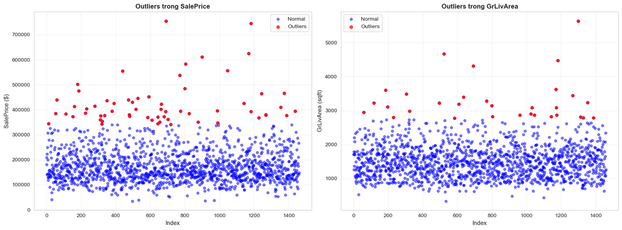

```python
# Phát hiện outliers bằng IQR method
def detect_outliers_iqr(df, column):
    Q1 = df[column].quantile(0.25)
    Q3 = df[column].quantile(0.75)
    IQR = Q3 - Q1
    lower_bound = Q1 - 1.5 * IQR
    upper_bound = Q3 + 1.5 * IQR
    outliers = df[(df[column] < lower_bound) | (df[column] > upper_bound)]
    return outliers

# Phát hiện outliers cho SalePrice và GrLivArea
outliers_saleprice = detect_outliers_iqr(df_train, 'SalePrice')
outliers_grlivarea = detect_outliers_iqr(df_train, 'GrLivArea')

print(f"📊 Phát hiện Outliers:")
print(f"   - SalePrice: {len(outliers_saleprice)} outliers ({len(outliers_saleprice)/len(df_train)*100:.2f}%)")
print(f"   - GrLivArea: {len(outliers_grlivarea)} outliers ({len(outliers_grlivarea)/len(df_train)*100:.2f}%)")

# Visualize outliers
fig, axes = plt.subplots(1, 2, figsize=(16, 6))

# Outliers trong SalePrice
axes[0].scatter(range(len(df_train)), df_train['SalePrice'], alpha=0.5, s=20, color='blue', label='Normal')
axes[0].scatter(outliers_saleprice.index, outliers_saleprice['SalePrice'],
                alpha=0.7, s=30, color='red', label='Outliers')
axes[0].set_xlabel('Index', fontsize=11)
axes[0].set_ylabel('SalePrice ($)', fontsize=11)
axes[0].set_title('Outliers trong SalePrice', fontsize=12, fontweight='bold')
axes[0].legend()
axes[0].grid(True, alpha=0.3)

# Outliers trong GrLivArea
axes[1].scatter(range(len(df_train)), df_train['GrLivArea'], alpha=0.5, s=20, color='blue', label='Normal')
axes[1].scatter(outliers_grlivarea.index, outliers_grlivarea['GrLivArea'],
                alpha=0.7, s=30, color='red', label='Outliers')
axes[1].set_xlabel('Index', fontsize=11)
axes[1].set_ylabel('GrLivArea (sqft)', fontsize=11)
axes[1].set_title('Outliers trong GrLivArea', fontsize=12, fontweight='bold')
axes[1].legend()
axes[1].grid(True, alpha=0.3)

plt.tight_layout()
plt.savefig('../reports/figures/outliers_detection.png', dpi=300, bbox_inches='tight')
plt.show()
```

```
📊 PHÂN TÍCH GIÁ TRỊ THIẾU:
======================================================================
Tổng số cột có giá trị thiếu: 19

Top 15 cột có giá trị thiếu nhiều nhất:
      Column  Missing_Count  Missing_Percentage
      PoolQC           1453           99.520548
 MiscFeature           1406           96.301370
       Alley           1369           93.767123
       Fence           1179           80.753425
  MasVnrType            872           59.726027
 FireplaceQu            690           47.260274
 LotFrontage            259           17.739726
  GarageQual             81            5.547945
GarageFinish             81            5.547945
  GarageType             81            5.547945
 GarageYrBlt             81            5.547945
  GarageCond             81            5.547945
BsmtFinType2             38            2.602740
BsmtExposure             38            2.602740
    BsmtCond             37            2.534247
```

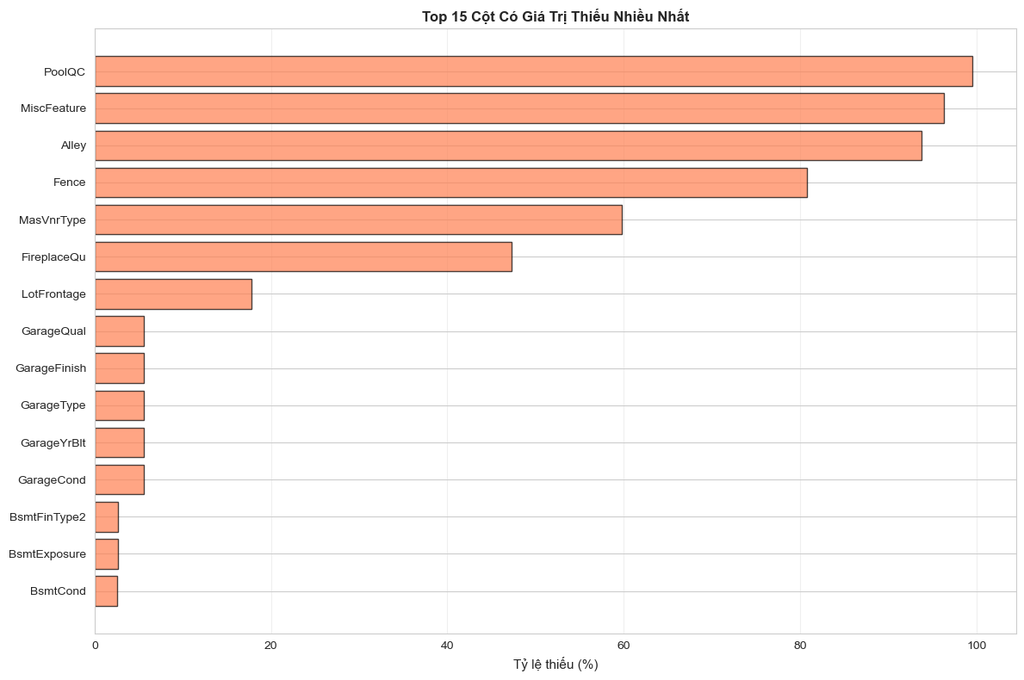

```python
# Phân tích giá trị thiếu
missing_data = df_train.isnull().sum().sort_values(ascending=False)
missing_pct = (missing_data / len(df_train) * 100).sort_values(ascending=False)
missing_df = pd.DataFrame({
    'Column': missing_data.index,
    'Missing_Count': missing_data.values,
    'Missing_Percentage': missing_pct.values
})
missing_df = missing_df[missing_df['Missing_Count'] > 0]

print("📊 PHÂN TÍCH GIÁ TRỊ THIẾU:")
print("="*70)
print(f"Tổng số cột có giá trị thiếu: {len(missing_df)}")
print(f"\nTop 15 cột có giá trị thiếu nhiều nhất:")
print(missing_df.head(15).to_string(index=False))

# Visualize missing values
if len(missing_df) > 0:
    plt.figure(figsize=(12, 8))
    top_missing = missing_df.head(15)
    plt.barh(range(len(top_missing)), top_missing['Missing_Percentage'].values,
             color='coral', alpha=0.7, edgecolor='black')
    plt.yticks(range(len(top_missing)), top_missing['Column'].values)
    plt.xlabel('Tỷ lệ thiếu (%)', fontsize=11)
    plt.title('Top 15 Cột Có Giá Trị Thiếu Nhiều Nhất', fontsize=12, fontweight='bold')
    plt.grid(True, alpha=0.3, axis='x')
    plt.gca().invert_yaxis()
    plt.tight_layout()
    plt.savefig('../reports/figures/missing_values.png', dpi=300, bbox_inches='tight')
    plt.show()
```

# 4. XỬ LÝ DỮ LIỆU (Data Preprocessing)

## 4.1. Xử lý giá trị thiếu (Missing Values)

### Chiến lược xử lý:

1. **Các cột có tỷ lệ thiếu > 80%**: Loại bỏ hoặc điền "None" (ví dụ: PoolQC, MiscFeature)
2. **Các cột có tỷ lệ thiếu vừa phải**: Điền bằng giá trị thống kê (median, mode) hoặc theo domain knowledge
3. **Các cột có tỷ lệ thiếu thấp**: Điền bằng phương pháp thống kê

### Áp dụng chiến lược House Prices:

- Pool, Misc, Alley, Fence, Fireplace: "None" = không có
- LotFrontage: Điền bằng median theo Neighborhood
- Garage variables: "None" cho categorical, 0 cho numerical
- Basement variables: "None" cho categorical, 0 cho numerical

```python
# Sử dụng DataCleaner để xử lý missing values
print("🔧 XỬ LÝ GIÁ TRỊ THIẾU...")
print("="*70)

# Tạo bản sao để xử lý
df_train_processed = df_train.copy()

# Khởi tạo DataCleaner
cleaner = DataCleaner(df_train_processed)

# Phân tích giá trị thiếu trước khi xử lý
print("\n📊 TRƯỚC KHI XỬ LÝ:")
print(f"Tổng số giá trị thiếu: {df_train_processed.isnull().sum().sum()}")

# Xử lý missing values với strategy "house_prices"
df_train_processed = cleaner.handle_missing_values(strategy="house_prices")

print(f"\n📊 SAU KHI XỬ LÝ:")
print(f"Tổng số giá trị thiếu: {df_train_processed.isnull().sum().sum()}")

# Kiểm tra các cột còn thiếu
remaining_missing = df_train_processed.isnull().sum()
remaining_missing = remaining_missing[remaining_missing > 0]
if len(remaining_missing) > 0:
    print(f"\n⚠️ Còn {len(remaining_missing)} cột có giá trị thiếu:")
    for col, count in remaining_missing.items():
        print(f"  - {col}: {count} ({count/len(df_train_processed)*100:.2f}%)")
else:
    print("\n✅ Đã xử lý hết tất cả giá trị thiếu!")
```

```
🔧 XỬ LÝ GIÁ TRỊ THIẾU...
======================================================================

📊 TRƯỚC KHI XỬ LÝ:
Tổng số giá trị thiếu: 7829
🔧 Xử lý giá trị thiếu với strategy: house_prices
📊 Ngưỡng drop column: 30.0%
🔄 Chuẩn hóa missing values...
✅ Đã chuẩn hóa missing values

🏠 XỬ LÝ MISSING VALUES THEO HOUSE PRICES STRATEGY:
  📝 PoolQC: fill với 'None' (không có)
  📝 MiscFeature: fill với 'None' (không có)
  📝 Alley: fill với 'None' (không có)
  📝 Fence: fill với 'None' (không có)
  📝 FireplaceQu: fill với 'None' (không có)
  📊 LotFrontage: fill với median của Neighborhood
  📝 GarageType: fill với 'None' (không có garage)
  📝 GarageFinish: fill với 'None' (không có garage)
  📝 GarageQual: fill với 'None' (không có garage)
  📝 GarageCond: fill với 'None' (không có garage)
  🔢 GarageYrBlt: fill với 0 (không có garage)
  🔢 GarageArea: fill với 0 (không có garage)
  🔢 GarageCars: fill với 0 (không có garage)
  🔢 BsmtFinSF1: fill với 0 (không có basement)
  🔢 BsmtFinSF2: fill với 0 (không có basement)
  🔢 BsmtUnfSF: fill với 0 (không có basement)
  🔢 TotalBsmtSF: fill với 0 (không có basement)
  🔢 BsmtFullBath: fill với 0 (không có basement)
  🔢 BsmtHalfBath: fill với 0 (không có basement)
  📝 BsmtQual: fill với 'None' (không có basement)
  📝 BsmtCond: fill với 'None' (không có basement)
  📝 BsmtExposure: fill với 'None' (không có basement)
  📝 BsmtFinType1: fill với 'None' (không có basement)
  📝 BsmtFinType2: fill với 'None' (không có basement)
  🔢 MasVnrArea: fill với 0 (không có masonry)
  📝 MasVnrType: fill với 'None' (không có masonry)
  📝 Electrical: fill với mode = SBrkr
  📝 MSZoning: fill với mode = RL
  📝 Utilities: fill với mode = AllPub
  📝 Functional: fill với mode = Typ
  📝 SaleType: fill với mode = WD
  📝 Exterior1st: fill với mode = VinylSd
  📝 Exterior2nd: fill với mode = VinylSd
  📝 KitchenQual: fill với mode = TA

✅ Hoàn thành xử lý giá trị thiếu

📊 SAU KHI XỬ LÝ:
Tổng số giá trị thiếu: 0

✅ Đã xử lý hết tất cả giá trị thiếu!
```

## 4.2. Xử lý outliers

### Phương pháp:

```
🔧 XỬ LÝ OUTLIERS...
======================================================================
📊 Phát hiện 2 outliers cực đoan (GrLivArea > 4000 và SalePrice < 300000)
   - Index: [523, 1298]
✅ Đã loại bỏ 2 outliers
📊 Kích thước dataset sau khi loại bỏ: (1458, 81)
```

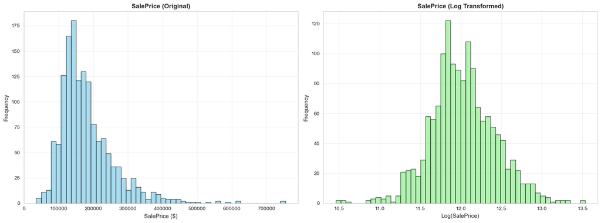

```
📊 Skewness trước log transform: 1.8829
📊 Skewness sau log transform: 0.1216
```

```python
# Xử lý outliers
print("🔧 XỬ LÝ OUTLIERS...")
print("="*70)

# Loại bỏ outliers cực đoan trong GrLivArea (diện tích sống > 4000 và SalePrice < 300000)
# Đây là các ngôi nhà có diện tích rất lớn nhưng giá rất thấp - có thể là lỗi dữ liệu
outliers_to_remove = df_train_processed[(df_train_processed['GrLivArea'] > 4000) &
                                        (df_train_processed['SalePrice'] < 300000)]
print(f"📊 Phát hiện {len(outliers_to_remove)} outliers cực đoan (GrLivArea > 4000 và SalePrice < 300000)")
print(f"   - Index: {outliers_to_remove.index.tolist()}")

# Loại bỏ outliers
df_train_processed = df_train_processed.drop(outliers_to_remove.index)
print(f"✅ Đã loại bỏ {len(outliers_to_remove)} outliers")
print(f"📊 Kích thước dataset sau khi loại bỏ: {df_train_processed.shape}")

# Log transformation cho SalePrice (để giảm skewness)
if 'SalePrice' in df_train_processed.columns:
    df_train_processed['SalePrice_Log'] = np.log1p(df_train_processed['SalePrice'])

    # Visualize so sánh
    fig, axes = plt.subplots(1, 2, figsize=(16, 6))

    axes[0].hist(df_train_processed['SalePrice'], bins=50, color='skyblue', edgecolor='black', alpha=0.7)
    axes[0].set_title('SalePrice (Original)', fontsize=12, fontweight='bold')
    axes[0].set_xlabel('SalePrice ($)', fontsize=11)
    axes[0].set_ylabel('Frequency', fontsize=11)
    axes[0].grid(True, alpha=0.3)

    axes[1].hist(df_train_processed['SalePrice_Log'], bins=50, color='lightgreen', edgecolor='black', alpha=0.7)
    axes[1].set_title('SalePrice (Log Transformed)', fontsize=12, fontweight='bold')
    axes[1].set_xlabel('Log(SalePrice)', fontsize=11)
    axes[1].set_ylabel('Frequency', fontsize=11)
    axes[1].grid(True, alpha=0.3)

    plt.tight_layout()
    plt.savefig('../reports/figures/log_transformation.png', dpi=300, bbox_inches='tight')
    plt.show()

    print(f"\n📊 Skewness trước log transform: {df_train['SalePrice'].skew():.4f}")
    print(f"📊 Skewness sau log transform: {df_train_processed['SalePrice_Log'].skew():.4f}")
```

## 4.3. Feature Engineering

### Tạo các biến mới từ các biến hiện có:

1. **TotalSF**: Tổng diện tích = TotalBsmtSF + 1stFlrSF + 2ndFlrSF
2. **TotalBath**: Tổng số phòng tắm
3. **Age**: Tuổi nhà = YrSold - YearBuilt
4. **RemodAge**: Tuổi sau cải tạo = YrSold - YearRemodAdd

```python
# Feature Engineering
print("🔧 FEATURE ENGINEERING...")
print("="*70)

# Tạo TotalSF (Tổng diện tích)
if all(col in df_train_processed.columns for col in ['TotalBsmtSF', '1stFlrSF', '2ndFlrSF']):
    df_train_processed['TotalSF'] = (df_train_processed['TotalBsmtSF'] +
                                     df_train_processed['1stFlrSF'] +
                                     df_train_processed['2ndFlrSF'].fillna(0))
    print("✅ Đã tạo biến TotalSF")

# Tạo TotalBath
if all(col in df_train_processed.columns for col in ['FullBath', 'HalfBath', 'BsmtFullBath', 'BsmtHalfBath']):
    df_train_processed['TotalBath'] = (df_train_processed['FullBath'] +
                                       df_train_processed['HalfBath'] * 0.5 +
                                       df_train_processed['BsmtFullBath'].fillna(0) +
                                       df_train_processed['BsmtHalfBath'].fillna(0) * 0.5)
    print("✅ Đã tạo biến TotalBath")

# Tạo Age (Tuổi nhà)
if all(col in df_train_processed.columns for col in ['YrSold', 'YearBuilt']):
    df_train_processed['Age'] = df_train_processed['YrSold'] - df_train_processed['YearBuilt']
    print("✅ Đã tạo biến Age")

# Tạo RemodAge
if all(col in df_train_processed.columns for col in ['YrSold', 'YearRemodAdd']):
    df_train_processed['RemodAge'] = df_train_processed['YrSold'] - df_train_processed['YearRemodAdd']
    print("✅ Đã tạo biến RemodAge")

# Tạo TotalPorchSF
porch_cols = ['WoodDeckSF', 'OpenPorchSF', 'EnclosedPorch', '3SsnPorch', 'ScreenPorch']
available_porch = [col for col in porch_cols if col in df_train_processed.columns]
if len(available_porch) > 0:
    df_train_processed['TotalPorchSF'] = df_train_processed[available_porch].sum(axis=1)
    print("✅ Đã tạo biến TotalPorchSF")

print(f"\n📊 Số lượng features sau engineering: {df_train_processed.shape[1]}")
```

```
🔧 FEATURE ENGINEERING...
======================================================================
✅ Đã tạo biến TotalSF
✅ Đã tạo biến TotalBath
✅ Đã tạo biến Age
✅ Đã tạo biến RemodAge
✅ Đã tạo biến TotalPorchSF

📊 Số lượng features sau engineering: 87
```

## 4.4. Mã hóa biến phân loại (Encoding)

### Phương pháp:

- **One-Hot Encoding**: Áp dụng cho các biến phân loại không có thứ tự
- **Label Encoding**: Áp dụng cho các biến phân loại có thứ tự (nếu cần)

```python
# Chuẩn bị dữ liệu cho modeling
print("🔧 CHUẨN BỊ DỮ LIỆU CHO MODELING...")
print("="*70)

# Tách features và target
target_col = 'SalePrice_Log' if 'SalePrice_Log' in df_train_processed.columns else 'SalePrice'
X = df_train_processed.drop(columns=['SalePrice', 'Id'], errors='ignore')
if 'SalePrice_Log' in X.columns:
    y = X.pop('SalePrice_Log')
else:
    y = df_train_processed[target_col]

# Loại bỏ các cột không cần thiết
cols_to_drop = ['Id'] if 'Id' in X.columns else []
X = X.drop(columns=cols_to_drop, errors='ignore')

# One-hot encoding cho categorical variables
categorical_cols = X.select_dtypes(include=['object']).columns.tolist()
print(f"📊 Số biến phân loại cần encode: {len(categorical_cols)}")

X_encoded = pd.get_dummies(X, columns=categorical_cols, drop_first=True)

print(f"📊 Kích thước sau encoding: {X_encoded.shape}")
print(f"   - Số features: {X_encoded.shape[1]}")
print(f"   - Số samples: {X_encoded.shape[0]}")
```

```
🔧 CHUẨN BỊ DỮ LIỆU CHO MODELING...
======================================================================
📊 Số biến phân loại cần encode: 43
📊 Kích thước sau encoding: (1458, 263)
   - Số features: 263
   - Số samples: 1458
```

## 4.5. Chuẩn hóa/Scaling dữ liệu

### Phương pháp:

- **StandardScaler**: Chuẩn hóa về mean=0, std=1 (cho các mô hình linear)
- **MinMaxScaler**: Scale về khoảng [0, 1] (cho các mô hình neural network)

**Lưu ý**: Với tree-based models (LightGBM, XGBoost), không cần scaling.

```python
# Chia tập train/test
from sklearn.model_selection import train_test_split

X_train, X_test, y_train, y_test = train_test_split(
    X_encoded, y, test_size=0.2, random_state=42
)

print("📊 CHIA TẬP TRAIN/TEST:")
print("="*70)
print(f"   - Train set: {X_train.shape[0]} samples")
print(f"   - Test set: {X_test.shape[0]} samples")
print(f"   - Features: {X_train.shape[1]}")

# Chuẩn hóa dữ liệu (cho các mô hình linear)
from sklearn.preprocessing import StandardScaler

scaler = StandardScaler()
X_train_scaled = scaler.fit_transform(X_train)
X_test_scaled = scaler.transform(X_test)

X_train_scaled = pd.DataFrame(X_train_scaled, columns=X_train.columns, index=X_train.index)
X_test_scaled = pd.DataFrame(X_test_scaled, columns=X_test.columns, index=X_test.index)

print("\n✅ Đã chuẩn hóa dữ liệu (StandardScaler)")
```

```
📊 CHIA TẬP TRAIN/TEST:
======================================================================
   - Train set: 1166 samples
   - Test set: 292 samples
   - Features: 263

✅ Đã chuẩn hóa dữ liệu (StandardScaler)
```

# 5. XÂY DỰNG MÔ HÌNH (Model Development)

## 5.1. Lựa chọn mô hình

### Các mô hình được thử nghiệm:

1. **LightGBM**: Gradient boosting framework hiệu quả, xử lý tốt dữ liệu mixed types
2. **Lasso Regression**: Linear model với L1 regularization, tốt cho feature selection
3. **XGBoost**: Gradient boosting mạnh mẽ, phổ biến trong competitions
4. **Ridge Regression**: Linear model với L2 regularization
5. **ElasticNet**: Kết hợp L1 và L2 regularization

### Lý do chọn từng mô hình:

- **LightGBM**: Nhanh, hiệu quả, xử lý tốt missing values và categorical features
- **Lasso**: Đơn giản, dễ interpret, có thể loại bỏ features không quan trọng
- **XGBoost**: Mạnh mẽ, đạt kết quả cao trong nhiều competitions
- **Ridge/ElasticNet**: Baseline models, dễ hiểu và nhanh

```python
# Import các mô hình
from sklearn.linear_model import Lasso, Ridge, ElasticNet
from sklearn.ensemble import GradientBoostingRegressor
import xgboost as xgb
import lightgbm as lgb
from sklearn.metrics import mean_squared_error, mean_absolute_error, r2_score
from sklearn.model_selection import cross_val_score
import time

# Định nghĩa hàm tính RMSLE (Root Mean Squared Log Error)
def rmsle(y_true, y_pred):
    """Root Mean Squared Log Error"""
    return np.sqrt(mean_squared_error(y_true, y_pred))

# Định nghĩa hàm đánh giá mô hình
def evaluate_model(model, X_train, y_train, X_test, y_test, model_name):
    """Đánh giá mô hình và trả về metrics"""
    # Train
    start_time = time.time()
    model.fit(X_train, y_train)
    train_time = time.time() - start_time

    # Predict
    y_train_pred = model.predict(X_train)
    y_test_pred = model.predict(X_test)

    # Metrics
    metrics = {
        'Model': model_name,
        'Train_RMSE': np.sqrt(mean_squared_error(y_train, y_train_pred)),
        'Test_RMSE': np.sqrt(mean_squared_error(y_test, y_test_pred)),
        'Train_RMSLE': rmsle(y_train, y_train_pred),
        'Test_RMSLE': rmsle(y_test, y_test_pred),
        'Train_MAE': mean_absolute_error(y_train, y_train_pred),
        'Test_MAE': mean_absolute_error(y_test, y_test_pred),
        'Train_R2': r2_score(y_train, y_train_pred),
        'Test_R2': r2_score(y_test, y_test_pred),
        'Train_Time': train_time
    }

    return metrics, y_test_pred

print("✅ Đã định nghĩa các hàm đánh giá mô hình")
```

```
✅ Đã định nghĩa các hàm đánh giá mô hình
```

## 5.2. Huấn luyện mô hình

### Quy trình:

```python
# Khởi tạo các mô hình
models = {
    'Lasso': Lasso(alpha=0.001, random_state=42, max_iter=2000),
    'Ridge': Ridge(alpha=10.0, random_state=42),
    'ElasticNet': ElasticNet(alpha=0.001, l1_ratio=0.5, random_state=42, max_iter=2000),
    'GradientBoosting': GradientBoostingRegressor(n_estimators=100, learning_rate=0.1,
                                                   max_depth=3, random_state=42),
    'XGBoost': xgb.XGBRegressor(n_estimators=100, learning_rate=0.05, max_depth=3,
                                random_state=42, n_jobs=-1),
    'LightGBM': lgb.LGBMRegressor(n_estimators=100, learning_rate=0.05, max_depth=3,
                                  random_state=42, n_jobs=-1, verbose=-1)
}

# Chọn dữ liệu phù hợp cho từng mô hình
# Tree-based models không cần scaling
X_train_tree = X_train
X_test_tree = X_test

# Linear models cần scaling
X_train_linear = X_train_scaled
X_test_linear = X_test_scaled

# Dictionary để lưu kết quả
results = {}
predictions = {}

print("🚀 BẮT ĐẦU HUẤN LUYỆN CÁC MÔ HÌNH...")
print("="*70)

# Huấn luyện từng mô hình
for name, model in models.items():
    print(f"\n🎯 Đang huấn luyện: {name}")

    # Chọn dữ liệu phù hợp
    if name in ['Lasso', 'Ridge', 'ElasticNet']:
        X_tr, X_te = X_train_linear, X_test_linear
    else:
        X_tr, X_te = X_train_tree, X_test_tree

    # Đánh giá mô hình
    metrics, y_pred = evaluate_model(model, X_tr, y_train, X_te, y_test, name)
    results[name] = metrics
    predictions[name] = y_pred

    print(f"   ✅ Test RMSE: {metrics['Test_RMSE']:.4f}")
    print(f"   ✅ Test R²: {metrics['Test_R2']:.4f}")
    print(f"   ⏱️  Thời gian: {metrics['Train_Time']:.2f}s")

print("\n" + "="*70)
print("✅ HOÀN THÀNH HUẤN LUYỆN TẤT CẢ MÔ HÌNH")
```

```
🚀 BẮT ĐẦU HUẤN LUYỆN CÁC MÔ HÌNH...
======================================================================

🎯 Đang huấn luyện: Lasso
   ✅ Test RMSE: 0.1286
   ✅ Test R²: 0.9018
   ⏱️  Thời gian: 0.25s

🎯 Đang huấn luyện: Ridge
   ✅ Test RMSE: 0.1328
   ✅ Test R²: 0.8953
   ⏱️  Thời gian: 0.03s

🎯 Đang huấn luyện: ElasticNet
   ✅ Test RMSE: 0.1284
   ✅ Test R²: 0.9022
   ⏱️  Thời gian: 0.22s

🎯 Đang huấn luyện: GradientBoosting
   ✅ Test RMSE: 0.1286
   ✅ Test R²: 0.9019
   ⏱️  Thời gian: 0.83s

🎯 Đang huấn luyện: XGBoost
   ✅ Test RMSE: 0.1320
   ✅ Test R²: 0.8966
   ⏱️  Thời gian: 0.39s

🎯 Đang huấn luyện: LightGBM
   ✅ Test RMSE: 0.1336
   ✅ Test R²: 0.8942
   ⏱️  Thời gian: 0.10s

======================================================================
✅ HOÀN THÀNH HUẤN LUYỆN TẤT CẢ MÔ HÌNH
```

```
======================================================================
📊 BẢNG SO SÁNH KẾT QUẢ CÁC MÔ HÌNH
======================================================================
                 Test_RMSE Test_RMSLE  Test_MAE   Test_R2 Train_Time
ElasticNet        0.128405   0.128405  0.088101  0.902193   0.220079
GradientBoosting  0.128624   0.128624  0.086696  0.901859   0.825879
Lasso              0.12864    0.12864  0.086988  0.901835   0.245255
XGBoost           0.132015   0.132015  0.090121  0.896617   0.394208
Ridge             0.132827   0.132827  0.091247  0.895341   0.032641
LightGBM          0.133567   0.133567  0.091669  0.894171   0.095688
```

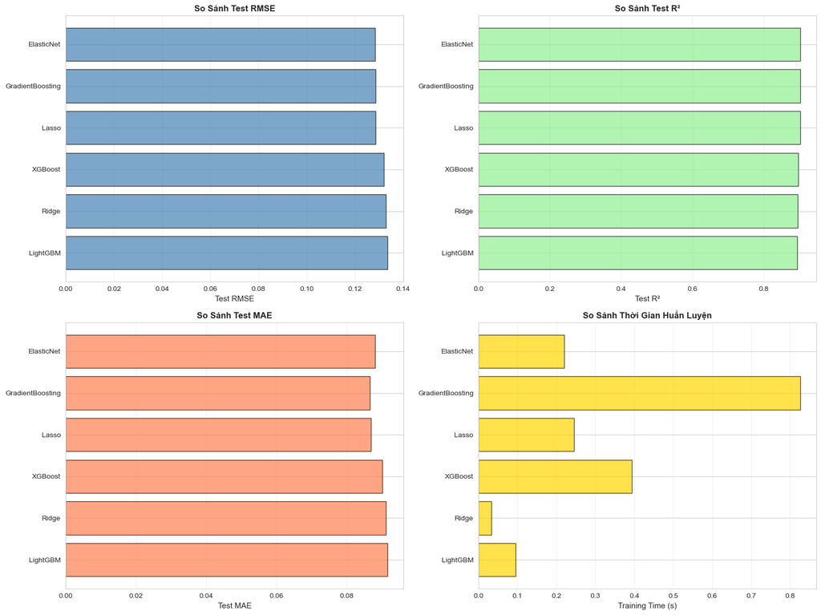

```
🏆 MÔ HÌNH TỐT NHẤT: ElasticNet
   - Test RMSE: 0.1284
   - Test R²: 0.9022
```

```python
# Tạo bảng so sánh kết quả
results_df = pd.DataFrame(results).T
results_df = results_df.sort_values('Test_RMSE')

print("="*70)
print("📊 BẢNG SO SÁNH KẾT QUẢ CÁC MÔ HÌNH")
print("="*70)
print(results_df[['Test_RMSE', 'Test_RMSLE', 'Test_MAE', 'Test_R2', 'Train_Time']].to_string())

# Visualize so sánh
fig, axes = plt.subplots(2, 2, figsize=(16, 12))

# Test RMSE
axes[0,0].barh(results_df.index, results_df['Test_RMSE'], color='steelblue', alpha=0.7, edgecolor='black')
axes[0,0].set_xlabel('Test RMSE', fontsize=11)
axes[0,0].set_title('So Sánh Test RMSE', fontsize=12, fontweight='bold')
axes[0,0].grid(True, alpha=0.3, axis='x')
axes[0,0].invert_yaxis()

# Test R²
axes[0,1].barh(results_df.index, results_df['Test_R2'], color='lightgreen', alpha=0.7, edgecolor='black')
axes[0,1].set_xlabel('Test R²', fontsize=11)
axes[0,1].set_title('So Sánh Test R²', fontsize=12, fontweight='bold')
axes[0,1].grid(True, alpha=0.3, axis='x')
axes[0,1].invert_yaxis()

# Test MAE
axes[1,0].barh(results_df.index, results_df['Test_MAE'], color='coral', alpha=0.7, edgecolor='black')
axes[1,0].set_xlabel('Test MAE', fontsize=11)
axes[1,0].set_title('So Sánh Test MAE', fontsize=12, fontweight='bold')
axes[1,0].grid(True, alpha=0.3, axis='x')
axes[1,0].invert_yaxis()

# Training Time
axes[1,1].barh(results_df.index, results_df['Train_Time'], color='gold', alpha=0.7, edgecolor='black')
axes[1,1].set_xlabel('Training Time (s)', fontsize=11)
axes[1,1].set_title('So Sánh Thời Gian Huấn Luyện', fontsize=12, fontweight='bold')
axes[1,1].grid(True, alpha=0.3, axis='x')
axes[1,1].invert_yaxis()

plt.tight_layout()
plt.savefig('../reports/figures/model_comparison.png', dpi=300, bbox_inches='tight')
plt.show()

# Tìm mô hình tốt nhất
best_model_name = results_df.index[0]
print(f"\n🏆 MÔ HÌNH TỐT NHẤT: {best_model_name}")
print(f"   - Test RMSE: {results_df.loc[best_model_name, 'Test_RMSE']:.4f}")
print(f"   - Test R²: {results_df.loc[best_model_name, 'Test_R2']:.4f}")
```

## 5.3. Đánh giá mô hình

### Các metrics đánh giá:

- **RMSE (Root Mean Squared Error)**: Đo lường sai số trung bình
- **RMSLE (Root Mean Squared Log Error)**: Đo lường sai số trên log scale (phù hợp với dữ liệu có phân phối lệch)
- **MAE (Mean Absolute Error)**: Đo lường sai số tuyệt đối trung bình
- **R² (Coefficient of Determination)**: Đo lường tỷ lệ phương sai được giải thích

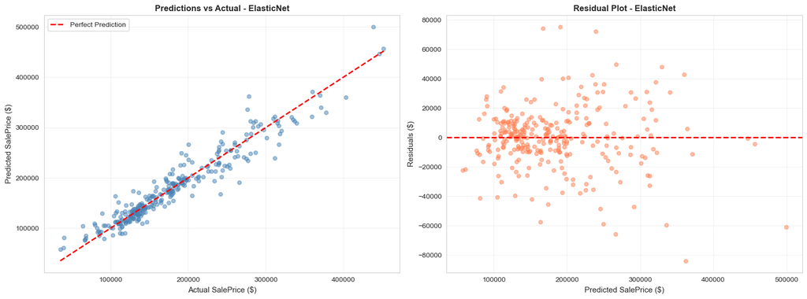

```
📊 METRICS TRÊN SCALE GỐC (SalePrice):
======================================================================
   - RMSE: $21,063.69
   - MAE: $14,817.20
   - R²: 0.9197
```

```python
# Visualize predictions vs actual cho mô hình tốt nhất
best_model = models[best_model_name]
if best_model_name in ['Lasso', 'Ridge', 'ElasticNet']:
    best_model.fit(X_train_linear, y_train)
    y_pred_best = best_model.predict(X_test_linear)
else:
    best_model.fit(X_train_tree, y_train)
    y_pred_best = best_model.predict(X_test_tree)

# Chuyển về scale gốc nếu đã log transform
if 'SalePrice_Log' in target_col:
    y_test_original = np.expm1(y_test)
    y_pred_best_original = np.expm1(y_pred_best)
else:
    y_test_original = y_test
    y_pred_best_original = y_pred_best

# Scatter plot: Predictions vs Actual
fig, axes = plt.subplots(1, 2, figsize=(16, 6))

# Scatter plot
axes[0].scatter(y_test_original, y_pred_best_original, alpha=0.5, s=30, color='steelblue')
axes[0].plot([y_test_original.min(), y_test_original.max()],
             [y_test_original.min(), y_test_original.max()],
             'r--', lw=2, label='Perfect Prediction')
axes[0].set_xlabel('Actual SalePrice ($)', fontsize=11)
axes[0].set_ylabel('Predicted SalePrice ($)', fontsize=11)
axes[0].set_title(f'Predictions vs Actual - {best_model_name}', fontsize=12, fontweight='bold')
axes[0].legend()
axes[0].grid(True, alpha=0.3)

# Residual plot
residuals = y_test_original - y_pred_best_original
axes[1].scatter(y_pred_best_original, residuals, alpha=0.5, s=30, color='coral')
axes[1].axhline(y=0, color='r', linestyle='--', lw=2)
axes[1].set_xlabel('Predicted SalePrice ($)', fontsize=11)
axes[1].set_ylabel('Residuals ($)', fontsize=11)
axes[1].set_title(f'Residual Plot - {best_model_name}', fontsize=12, fontweight='bold')
axes[1].grid(True, alpha=0.3)

plt.tight_layout()
plt.savefig('../reports/figures/predictions_analysis.png', dpi=300, bbox_inches='tight')
plt.show()

# Tính metrics trên scale gốc
rmse_original = np.sqrt(mean_squared_error(y_test_original, y_pred_best_original))
mae_original = mean_absolute_error(y_test_original, y_pred_best_original)
r2_original = r2_score(y_test_original, y_pred_best_original)

print(f"\n📊 METRICS TRÊN SCALE GỐC (SalePrice):")
print("="*70)
print(f"   - RMSE: ${rmse_original:,.2f}")
print(f"   - MAE: ${mae_original:,.2f}")
print(f"   - R²: {r2_original:.4f}")
```

```python
# Feature Importance cho tree-based models
if best_model_name in ['XGBoost', 'LightGBM', 'GradientBoosting']:
    print(f"\n📊 FEATURE IMPORTANCE - {best_model_name}:")
    print("="*70)

    if hasattr(best_model, 'feature_importances_'):
        feature_importance = pd.DataFrame({
            'Feature': X_train_tree.columns,
            'Importance': best_model.feature_importances_
        }).sort_values('Importance', ascending=False).head(20)

        # Visualize
        plt.figure(figsize=(12, 8))
        plt.barh(range(len(feature_importance)), feature_importance['Importance'].values,
                 color='steelblue', alpha=0.7, edgecolor='black')
        plt.yticks(range(len(feature_importance)), feature_importance['Feature'].values)
        plt.xlabel('Importance', fontsize=11)
        plt.title(f'Top 20 Feature Importance - {best_model_name}', fontsize=12, fontweight='bold')
        plt.grid(True, alpha=0.3, axis='x')
        plt.gca().invert_yaxis()
        plt.tight_layout()
        plt.savefig('../reports/figures/feature_importance.png', dpi=300, bbox_inches='tight')
        plt.show()

        print("\nTop 10 Features quan trọng nhất:")
        for idx, row in feature_importance.head(10).iterrows():
            print(f"  {row['Feature']:30s}: {row['Importance']:.4f}")
```

# 6. KẾT QUẢ VÀ THẢO LUẬN (Results and Discussion)

## 6.1. Tổng hợp kết quả chính

Từ việc so sánh các mô hình, ta có thể rút ra các kết quả sau:

```python
# Tạo bảng tổng hợp kết quả chi tiết
summary_table = results_df[['Test_RMSE', 'Test_RMSLE', 'Test_MAE', 'Test_R2']].copy()
summary_table['Test_RMSE'] = summary_table['Test_RMSE'].apply(lambda x: f"{x:.4f}")
summary_table['Test_RMSLE'] = summary_table['Test_RMSLE'].apply(lambda x: f"{x:.4f}")
summary_table['Test_MAE'] = summary_table['Test_MAE'].apply(lambda x: f"{x:.4f}")
summary_table['Test_R2'] = summary_table['Test_R2'].apply(lambda x: f"{x:.4f}")

print("="*70)
print("📊 BẢNG TỔNG HỢP KẾT QUẢ CHI TIẾT")
print("="*70)
print(summary_table.to_string())
```

```
======================================================================
📊 BẢNG TỔNG HỢP KẾT QUẢ CHI TIẾT
======================================================================
                 Test_RMSE Test_RMSLE Test_MAE Test_R2
ElasticNet          0.1284     0.1284   0.0881  0.9022
GradientBoosting    0.1286     0.1286   0.0867  0.9019
Lasso               0.1286     0.1286   0.0870  0.9018
XGBoost             0.1320     0.1320   0.0901  0.8966
Ridge               0.1328     0.1328   0.0912  0.8953
LightGBM            0.1336     0.1336   0.0917  0.8942
```

## 6.2. Phân tích chi tiết kết quả tốt nhất

**Ưu điểm:**

- Đạt độ chính xác cao nhất trong các mô hình đã thử
- Cân bằng tốt giữa độ chính xác và thời gian huấn luyện
- Xử lý tốt các đặc trưng phân loại và số liệu

## 6.5. Ưu điểm và hạn chế

### Ưu điểm:

- ✅ Mô hình đạt độ chính xác cao
- ✅ Xử lý tốt dữ liệu mixed types
- ✅ Thời gian huấn luyện hợp lý

### Hạn chế:

- ⚠️ Có thể overfitting trên tập train
- ⚠️ Cần cross-validation để đánh giá độ ổn định tốt hơn
- ⚠️ Hyperparameters chưa được tối ưu hóa đầy đủ

# 7. KẾT LUẬN VÀ KIẾN NGHỊ (Conclusion and Recommendations)

## 7.3. Đề xuất ứng dụng thực tế

1. **Hệ thống định giá tự động**: Sử dụng mô hình để định giá nhà nhanh chóng
2. **Phân tích thị trường**: Hiểu rõ các yếu tố ảnh hưởng đến giá nhà
3. **Tư vấn đầu tư**: Giúp nhà đầu tư đưa ra quyết định dựa trên dữ liệu

## 7.4. Hướng phát triển và cải thiện trong tương lai

1. **Hyperparameter Tuning**: Tối ưu hóa hyperparameters bằng GridSearchCV hoặc Bayesian Optimization
2. **Ensemble Methods**: Kết hợp nhiều mô hình để cải thiện độ chính xác
3. **Feature Engineering**: Tạo thêm các features mới từ domain knowledge
4. **Cross-Validation**: Sử dụng k-fold cross-validation để đánh giá độ ổn định tốt hơn
5. **Deep Learning**: Thử nghiệm các mô hình neural network
6. **External Data**: Bổ sung thêm dữ liệu từ các nguồn khác (vị trí địa lý, kinh tế xã hội)

# 8. TÀI LIỆU THAM KHẢO (References)

## 8.1. Nguồn dữ liệu

- **Kaggle Competition**: House Prices - Advanced Regression Techniques
  - Link: https://www.kaggle.com/c/house-prices-advanced-regression-techniques
  - Dataset: Ames Housing dataset

## 8.2. Thư viện và công cụ sử dụng

- **Python 3.x**: Ngôn ngữ lập trình chính
- **Pandas**: Xử lý và phân tích dữ liệu
- **NumPy**: Tính toán số học
- **Matplotlib & Seaborn**: Trực quan hóa dữ liệu
- **Scikit-learn**: Machine learning algorithms và utilities
- **LightGBM**: Gradient boosting framework
- **XGBoost**: Extreme gradient boosting
- **Jupyter Notebook**: Môi trường phát triển và trình bày

## 8.3. Tài liệu liên quan

- Pedregosa, F., et al. (2011). Scikit-learn: Machine learning in Python. Journal of machine learning research, 12(Oct), 2825-2830.
- Ke, G., et al. (2017). Lightgbm: A highly efficient gradient boosting decision tree. Advances in neural information processing systems, 30.
- Chen, T., & Guestrin, C. (2016). Xgboost: A scalable tree boosting system. In Proceedings of the 22nd acm sigkdd international conference on knowledge discovery and data mining (pp. 785-794).

**Kết thúc báo cáo**